# Part II - (Analysis for San Francisco Bay Ford GoBike Service)

## by (Caleb Okon)

## Investigation Overview

In this investigation, I examined the Ride duration of each user_type and find out relevant informations about each rides.

## Dataset Overview

This data set includes information about individual rides made in a bike-sharing system covering the greater San Francisco Bay area. information collated in this dataset includes the following 'duration_sec', 'start_time', 'end_time', 'start_station_id','start_station_name','start_station_latitude','start_station_longitude','end_station_id','end_station_name','end_station_latitude','end_station_longitude','bike_id','user_type','member_birth_year','member_gender' and 'bike_share_for_all_trip'.

## Usage based on User type

> There are two types of users(subscribers and customers) and majority of the user_type are subscribers and this constitute about 89.2% of the riders while 10.8% constitutes users that are customers.

```
<function matplotlib.pyplot.show(*args, **kw)>
```

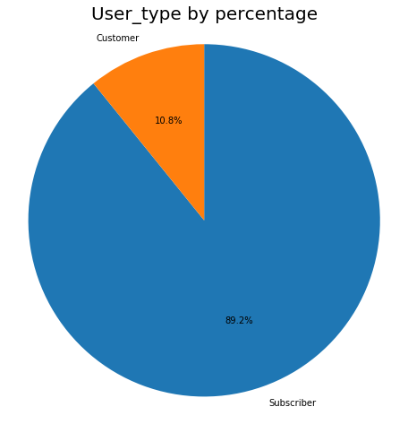

## Hours of Start Rides

> most rides started in the morning 7am-9am and in the evening between 4pm-7pm. this might be because most work resumes and close within those period

```
<function matplotlib.pyplot.show(*args, **kw)>
```

[figure not shown]

## Relationship between user_type and duration minutes

> most subscribers riders rode for 7-13 minutes and most customers rode for 10-15 minutes. also, more customers rode for more than one hour when compared to that of subscribers.

```
<function matplotlib.pyplot.show(*args, **kw)>
```

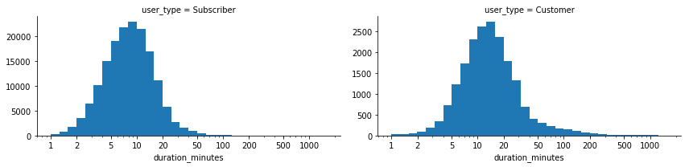

## Duration usage in each Hour

1. subscribers seems to have a similar duration minute not above 20 minutes, unlike that of customers.
2. customers seems to spend more time riding in each hour than subscribers.
3. the duration at the odd hours of 2am and 3am is higher than other hours.

```
<function matplotlib.pyplot.show(*args, **kw)>
```

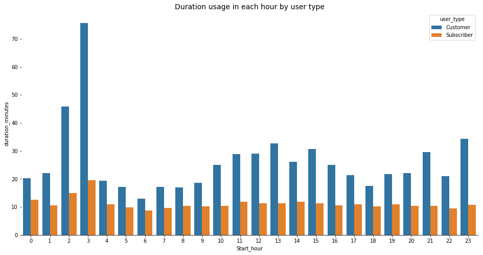